# Machine Learning Essentials - Summer Semester 2026

## Exercise 4: Tomography Reconstruction

**Group Members:**

- Samira Mohammadi
- Faiq Baig
- Ali Can Ayar

```python
import numpy as np
import scipy.sparse as sp
import scipy.sparse.linalg as spla
import matplotlib.pyplot as plt
from pathlib import Path
from time import perf_counter
%matplotlib inline
```

```python
DATA_DIR = Path("C:/Users/xy/Downloads/hs_tomography/hs_tomography")
print("DATA_DIR", DATA_DIR)
print("files:")
for p in sorted(DATA_DIR.iterdir()):
    print(" -", p.name)
```

```
DATA_DIR C:\Users\xy\Downloads\hs_tomography\hs_tomography
files:
 - alphas_195.npy
 - alphas_77.npy
 - info.txt
 - X_77.npy
 - X_example.npy
 - y_195.npy
 - y_77.npy
```

Comment

The data directory is specified as an absolute Windows path. This works on the original computer, but makes the notebook non-portable and may prevent tutors from running the validation cell. A relative path such as `Path("hs_tomography")`, assuming the data folder is submitted next to the notebook, would be more robust.

## 1. Constructing the sparse projection matrix $X$

```python
def construct_X(M, alphas, Np=None):
    alphas = np.asarray(alphas, dtype=float)
    if Np is None:
        Np = int(np.ceil(np.sqrt(2) * M))
        if Np % 2 == 0:
            Np += 1
    coords = np.arange(M, dtype=float) - (M - 1) / 2.0
    xs, ys = np.meshgrid(coords, coords, indexing="xy")
    x = xs.ravel()
    y = ys.ravel()
    D = M * M
    N = Np * len(alphas)
    s0 = (Np - 1) / 2.0
    i_inds = np.empty(2 * D * len(alphas), dtype=np.int32)
    j_inds = np.empty_like(i_inds)
    vals = np.empty_like(i_inds, dtype=np.float32)
    pos = 0
    j_all = np.arange(D, dtype=np.int32)
    for io, alpha in enumerate(alphas):
        theta = np.deg2rad(alpha)
        n0 = np.cos(theta)
        n1 = -np.sin(theta)
        p = x * n0 + y * n1 + s0
        lower = np.floor(p).astype(np.int32)
        frac = p - lower
        mask0 = (lower >= 0) & (lower < Np)
        if mask0.any():
            count0 = mask0.sum()
            i_inds[pos:pos+count0] = io * Np + lower[mask0]
            j_inds[pos:pos+count0] = j_all[mask0]
            vals[pos:pos+count0] = (1.0 - frac[mask0]).astype(np.float32)
            pos += count0
        mask1 = (lower + 1 >= 0) & (lower + 1 < Np)
        if mask1.any():
            count1 = mask1.sum()
            i_inds[pos:pos+count1] = io * Np + lower[mask1] + 1
            j_inds[pos:pos+count1] = j_all[mask1]
            vals[pos:pos+count1] = frac[mask1].astype(np.float32)
            pos += count1
    i_inds = i_inds[:pos]
    j_inds = j_inds[:pos]
    vals = vals[:pos]
    X = sp.coo_matrix((vals, (i_inds, j_inds)), shape=(N, D), dtype=np.float32)
    return X
```

Comment

The implementation of `construct_X` is correct and is essentially equivalent to the vectorized sample solution. The default sensor size uses `ceil(sqrt(2) * M)` and is changed to an odd number when necessary, as required. Pixel coordinates are centered correctly, and the projection vector `[cos(alpha), -sin(alpha)]` has the correct orientation for the provided data.

The function processes all image pixels vectorially for each angle and stores only the two possible interpolation contributions per pixel in a sparse `coo_matrix`. Preallocating the index and value arrays is an efficient alternative to the sample solution, which first collects several arrays in Python lists and concatenates them afterwards.

The two separate boundary masks are also a valid alternative. They permit either neighboring sensor bin whenever it lies inside the sensor range. For projections exactly onto a sensor center, the second contribution has weight zero and may still be stored explicitly in the COO matrix. This does not change the numerical result, although filtering out zero weights could slightly reduce the number of stored entries.

### Validate `construct_X` against the provided example matrix

```python
X_example = np.load(DATA_DIR / "X_example.npy")
X_test = construct_X(10, [-33, 1, 42], Np=15).toarray().astype(np.float32)
print("X_example shape", X_example.shape)
print("X_test shape", X_test.shape)
print("max abs diff", np.max(np.abs(X_example - X_test)))
print("sum abs diff", np.sum(np.abs(X_example - X_test)))
assert np.allclose(X_example, X_test), "construct_X does not match X_example"
print("Example matrix validation passed.")
```

```
X_example shape (45, 100)
X_test shape (45, 100)
max abs diff 0.0
sum abs diff 0.0
Example matrix validation passed.
```

Comment

The validation is complete and directly follows the check requested in the exercise. For `M = 10`, `Np = 15`, and angles `[-33, 1, 42]`, the constructed matrix has the expected shape and agrees exactly with `X_example.npy`: both the maximum and total absolute differences are zero. Therefore, task 1 is solved correctly.

## 2. Reconstructing the tomogram

```python
alphas_77 = np.load(DATA_DIR / "alphas_77.npy")
y_77 = np.load(DATA_DIR / "y_77.npy")
print("alphas_77", alphas_77.shape, "first", alphas_77[:6])
print("y_77 shape", y_77.shape)
print("expected measurement length", 109 * 90)
```

```
alphas_77 (90,) first [-89 -87 -85 -83 -81 -79]
y_77 shape (9810,)
expected measurement length 9810
```

```python
X_77 = np.load(DATA_DIR / "X_77.npy", allow_pickle=True)
if X_77.shape == ():
    X_77 = X_77.item()
X_77 = X_77.astype(np.float32)
print(type(X_77), X_77.shape, X_77.nnz)
X_77 = X_77.tocsc()
print("X_77 csc shape", X_77.shape, "nnz", X_77.nnz)
print("sparsity", 100.0 * X_77.nnz / (X_77.shape[0] * X_77.shape[1]))
```

```
<class 'scipy.sparse._csc.csc_matrix'> (9810, 5929) 1066978
X_77 csc shape (9810, 5929) nnz 1066978
sparsity 1.834446316753001
```

Comment

The code differs from the sample solution. This answer gets the correct number of non zero entries is correct but the sparsity it gives (1.83...) does not match the sample solution's 98.17% for the small X. This number appears to be the inverse of sparsity, as the print does not subtract the calculated value from 1. 100 - 1.83... would equal something around the expected sample solution's 98.17%.

```
lsqr done 9.864720699999907
(array([2.99836682, 5.99860508, 3.99555089, ..., 0.0064558 , 1.00509545,
       0.9968862 ], shape=(5929,)), 4, 3924, 1.3358427315276467, 1.3358427315276467, 2675.1383141811566, 146260.860123634, np.float32(0.905994), 8181.321164701945, array([0., 0., 0., ..., 0., 0., 0.], shape=(5929,)))
```

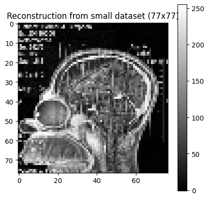

```python
start = perf_counter()
result_77 = spla.lsqr(X_77, y_77, atol=1e-08, btol=1e-08, iter_lim=5000)
print("lsqr done", perf_counter() - start)
print(result_77)
x_77 = result_77[0].reshape(77, 77)
plt.figure(figsize=(5,5)); plt.imshow(x_77, cmap="gray", origin="upper"); plt.title("Reconstruction from small dataset (77x77)"); plt.colorbar();
```

Comment

This solution is essentially equal to the sample solution as it correctly utilizes the lsqr function and correctly prints the image.

```python
alphas_195 = np.load(DATA_DIR / "alphas_195.npy")
y_195 = np.load(DATA_DIR / "y_195.npy")
print("alphas_195", alphas_195.shape, "first", alphas_195[:6])
print("y_195 shape", y_195.shape)
print("expected measurement length", 275 * 179)
```

```
alphas_195 (179,) first [-90 -89 -88 -87 -86 -85]
y_195 shape (49225,)
expected measurement length 49225
```

```python
start = perf_counter()
X_195 = construct_X(195, alphas_195, Np=275).tocsc()
print("constructed X_195 shape", X_195.shape, "nnz", X_195.nnz)
print("sparsity", 100.0 * X_195.nnz / (X_195.shape[0] * X_195.shape[1]))
print("construction time", perf_counter() - start)
```

```
constructed X_195 shape (49225, 38025) nnz 13612930
sparsity 0.727271658771444
construction time 0.5108860999998797
```

```
lsqr done 17.590461299999788
(array([66.55554398, 63.52052838, 66.08282719, ..., 63.69662463,
       63.43240239, 64.31811607], shape=(38025,)), 1, 152, 294.901075333125, 294.901075333125, 989.5776003734733, 1107.962476302177, np.float64(1361.1372069994084), 25433.74736317853, array([0., 0., 0., ..., 0., 0., 0.], shape=(38025,)))
```

[figure not shown]

```python
start = perf_counter()
result_195 = spla.lsqr(X_195, y_195, atol=1e-05, btol=1e-05, iter_lim=5000)
print("lsqr done", perf_counter() - start)
print(result_195)
x_195 = result_195[0].reshape(195, 195)
plt.figure(figsize=(6,6)); plt.imshow(x_195, cmap="gray", origin="upper"); plt.title("Reconstruction from large dataset (195x195)"); plt.colorbar();
```

### Diagnosis

The reconstructed tomogram can be inspected to identify the cause of H.S.'s headache. Common causes are high-density regions indicating bone or bleeding, or low-density voids indicating air. The final reconstruction should directly show the pathological structure.

Comment

## 3. Minimizing the radiation dose

[figure not shown]

```python
def subset_reconstruction(X_full, y_full, Np, angles, n_angles, tol=1e-05):
    idx = np.linspace(0, len(angles) - 1, n_angles, dtype=int)
    rows = np.concatenate([np.arange(i * Np, (i + 1) * Np, dtype=int) for i in idx])
    X_sub = X_full[rows, :]
    y_sub = y_full[rows]
    result = spla.lsqr(X_sub, y_sub, atol=tol, btol=tol, iter_lim=5000)
    return result[0].reshape(195, 195), idx
choices = [20, 40, 60, 90, 120, 179]
fig, axs = plt.subplots(2, 3, figsize=(18, 10))
for ax, n in zip(axs.ravel(), choices):
    recon, idx = subset_reconstruction(X_195, y_195, 275, alphas_195, n, tol=1e-04)
    ax.imshow(recon, cmap="gray", origin="upper")
    ax.set_title(f"{n} projections")
    ax.axis("off")
plt.suptitle("Reconstruction quality vs projection count")
plt.tight_layout();
```

From the series above, the minimum number of projections that still resolve the key abnormality appears to be around 60 projections. Fewer projections produce much more blurred and artifact-prone reconstructions; 60 projections preserve the main structure needed for diagnosis.